# HW3-Part 2 - Classification Models

Author

Suneri Airkar

Published

November 9, 2025

## Step 1 - Familiarize yourself with the data and the assignment

Save this file as a new Quarto Markdown document and name it something that includes your last name in the filename. Save it into the same folder as this file. Create a new R Studio Project based on this folder.

This assignment will focus on building simple classification models for predicting fetal health based on a number of clinical measurements known as *cardiotocographic data*.

The following introductory information was taken from the main [Kaggle Dataset page](https://www.kaggle.com/andrewmvd/fetal-health-classification) for this data:

> **Context**

> Reduction of child mortality is reflected in several of the United Nations’ Sustainable Development Goals and is a key indicator of human progress. The UN expects that by 2030, countries end preventable deaths of newborns and children under 5 years of age, with all countries aiming to reduce under‑5 mortality to at least as low as 25 per 1,000 live births.

> Parallel to notion of child mortality is of course maternal mortality, which accounts for 295 000 deaths during and following pregnancy and childbirth (as of 2017). The vast majority of these deaths (94%) occurred in low-resource settings, and most could have been prevented.

> In light of what was mentioned above, Cardiotocograms (CTGs) are a simple and cost accessible option to assess fetal health, allowing healthcare professionals to take action in order to prevent child and maternal mortality. The equipment itself works by sending ultrasound pulses and reading its response, thus shedding light on fetal heart rate (FHR), fetal movements, uterine contractions and more.

> **Data**

> This dataset contains 2126 records of features extracted from Cardiotocogram exams, which were then classified by three expert obstetritians into 3 classes:
> - Normal
> - Suspect
> - Pathological

The definitions of the columns are:

```
* baseline value - FHR baseline (beats per minute)
* accelerations - Number of accelerations per second
* fetal_movement - Number of fetal movements per second
* uterine_contractions - Number of uterine contractions per second
* light_decelerations - Number of light decelerations per second
* severe_decelerations - Number of severe decelerations per second
* prolongued_decelerations - Number of prolonged decelerations per second
* abnormal_short_term_variability - Percentage of time with abnormal short term variability
* mean_value_of_short_term_variability - Mean value of short term variability
* percentage_of_time_with_abnormal_long_term_variability - Percentage of time with abnormal long term variability
* mean_value_of_long_term_variability - Mean value of long term variability
* histogram_width - Width of FHR histogram
* histogram_min - Minimum (low frequency) of FHR histogram
* histogram_max - Maximum (high frequency) of FHR histogram
* histogram_number_of_peaks - Number of histogram peaks
* histogram_number_of_zeroes - Number of histogram zeros
* histogram_mode - Histogram mode
* histogram_mean - Histogram mean
* histogram_median - Histogram median
* histogram_variance - Histogram variance
* histogram_tendency - Histogram tendency
```

You can learn much more about the study behind this dataset from the following published paper:

- https://www.ncbi.nlm.nih.gov/pmc/articles/PMC6822315/

While in the original study and dataset, there were three classes for the target variable (Normal, Suspect, Pathological), we will convert this to a binary classification problem where 1 will be Suspect or Pathological and 0 will be Normal. Multi-class problems are a bit beyond the scope of this introduction to classification problems.

```r
library(dplyr)   # Group by analysis and other SQLish things.
library(ggplot2) # Plotting, of course
library(tidyr)   # Data reshaping
library(tidymodels)   # Many aspects of predictive modeling
library(corrplot)  # Correlation plots
library(skimr)       # An automated EDA tool (you saw this in a previous assignment)
library(rpart)
library(rpart.plot)
library(RColorBrewer)
library(vip)
```

## Step 2 - Load data

You’ll notice that there is a subfolder named **data**. Inside of it you’ll find the data file for this assignment:

- **fetal_health.csv**

### Load the data

```r
fetal_health <- read.csv("./data/fetal_health.csv")
```

Our target variable will be based on the `fetal_health` variable. Let’s check the current values.

```r
table(fetal_health$fetal_health)
```

```
   1    2    3
1655  295  176
```

Now we will recode the 1’s as a 0 and the 2’s and 3’s as a 1. I’m going to do this in a new column so that we can check and make sure we’ve got it right.

```r
fetal_health$b_fetal_health <- fetal_health$fetal_health
fetal_health$b_fetal_health[fetal_health$b_fetal_health == 1] <- 0
fetal_health$b_fetal_health[fetal_health$b_fetal_health >= 2] <- 1

table(fetal_health$b_fetal_health, fetal_health$fetal_health)
```

```
       1    2    3
  0 1655    0    0
  1    0  295  176
```

Looks good, let’s drop the original `fetal_health` column and convert the b_fetal_health` column to a factor. I’m explicitly setting the order of the factor levels so that “0” is the first level just so there’s no confusion.

```r
fetal_health <- fetal_health  |>
  select (!fetal_health)

fetal_health$b_fetal_health <- factor(fetal_health$b_fetal_health, levels=c("0", "1"))
```

Find the number of patients and the percentage of patients for the two fetal health levels - 1 and 2. You’ll see that there are about 78% of the patients with a normal fetal health assessment (i.e. `b_fetal_health` = 0)

```r
# Find the number and percentage of patients for two fetal health levels - 1 & 2
fetal_health %>%
  group_by(b_fetal_health) %>%
  summarise(n = n(),
    prop = round(100 * n / nrow(fetal_health), 2))
```

```
# A tibble: 2 × 3
  b_fetal_health     n  prop
  <fct>          <int> <dbl>
1 0               1655  77.8
2 1                471  22.2
```

> In total there are 2,126 patients. About 78% of them are normal (b_fetal_health = 0) and 22% are abnormal (b_fetal_health = 1).

Use `str`, `summary`, and `skim` to get a sense of the data. Our response variable, the thing we will be trying to predict is `b_fetal_health`.

```r
str(fetal_health)
```

```
'data.frame':   2126 obs. of  22 variables:
 $ baseline.value                                        : num  120 132 133 134 132 134 134 122 122 122 ...
 $ accelerations                                         : num  0 0.006 0.003 0.003 0.007 0.001 0.001 0 0 0 ...
 $ fetal_movement                                        : num  0 0 0 0 0 0 0 0 0 0 ...
 $ uterine_contractions                                  : num  0 0.006 0.008 0.008 0.008 0.01 0.013 0 0.002 0.003 ...
 $ light_decelerations                                   : num  0 0.003 0.003 0.003 0 0.009 0.008 0 0 0 ...
 $ severe_decelerations                                  : num  0 0 0 0 0 0 0 0 0 0 ...
 $ prolongued_decelerations                              : num  0 0 0 0 0 0.002 0.003 0 0 0 ...
 $ abnormal_short_term_variability                       : num  73 17 16 16 16 26 29 83 84 86 ...
 $ mean_value_of_short_term_variability                  : num  0.5 2.1 2.1 2.4 2.4 5.9 6.3 0.5 0.5 0.3 ...
 $ percentage_of_time_with_abnormal_long_term_variability: num  43 0 0 0 0 0 0 6 5 6 ...
 $ mean_value_of_long_term_variability                   : num  2.4 10.4 13.4 23 19.9 0 0 15.6 13.6 10.6 ...
 $ histogram_width                                       : num  64 130 130 117 117 150 150 68 68 68 ...
 $ histogram_min                                         : num  62 68 68 53 53 50 50 62 62 62 ...
 $ histogram_max                                         : num  126 198 198 170 170 200 200 130 130 130 ...
 $ histogram_number_of_peaks                             : num  2 6 5 11 9 5 6 0 0 1 ...
 $ histogram_number_of_zeroes                            : num  0 1 1 0 0 3 3 0 0 0 ...
 $ histogram_mode                                        : num  120 141 141 137 137 76 71 122 122 122 ...
 $ histogram_mean                                        : num  137 136 135 134 136 107 107 122 122 122 ...
 $ histogram_median                                      : num  121 140 138 137 138 107 106 123 123 123 ...
 $ histogram_variance                                    : num  73 12 13 13 11 170 215 3 3 1 ...
 $ histogram_tendency                                    : num  1 0 0 1 1 0 0 1 1 1 ...
 $ b_fetal_health                                        : Factor w/ 2 levels "0","1": 2 1 1 1 1 2 2 2 2 2 ...
```

```r
summary(fetal_health)
```

```
 baseline.value  accelerations      fetal_movement     uterine_contractions
 Min.   :106.0   Min.   :0.000000   Min.   :0.000000   Min.   :0.000000
 1st Qu.:126.0   1st Qu.:0.000000   1st Qu.:0.000000   1st Qu.:0.002000
 Median :133.0   Median :0.002000   Median :0.000000   Median :0.004000
 Mean   :133.3   Mean   :0.003178   Mean   :0.009481   Mean   :0.004366
 3rd Qu.:140.0   3rd Qu.:0.006000   3rd Qu.:0.003000   3rd Qu.:0.007000
 Max.   :160.0   Max.   :0.019000   Max.   :0.481000   Max.   :0.015000
 light_decelerations severe_decelerations prolongued_decelerations
 Min.   :0.000000    Min.   :0.000e+00    Min.   :0.0000000
 1st Qu.:0.000000    1st Qu.:0.000e+00    1st Qu.:0.0000000
 Median :0.000000    Median :0.000e+00    Median :0.0000000
 Mean   :0.001889    Mean   :3.293e-06    Mean   :0.0001585
 3rd Qu.:0.003000    3rd Qu.:0.000e+00    3rd Qu.:0.0000000
 Max.   :0.015000    Max.   :1.000e-03    Max.   :0.0050000
 abnormal_short_term_variability mean_value_of_short_term_variability
 Min.   :12.00                   Min.   :0.200
 1st Qu.:32.00                   1st Qu.:0.700
 Median :49.00                   Median :1.200
 Mean   :46.99                   Mean   :1.333
 3rd Qu.:61.00                   3rd Qu.:1.700
 Max.   :87.00                   Max.   :7.000
 percentage_of_time_with_abnormal_long_term_variability
 Min.   : 0.000
 1st Qu.: 0.000
 Median : 0.000
 Mean   : 9.847
 3rd Qu.:11.000
 Max.   :91.000
 mean_value_of_long_term_variability histogram_width  histogram_min
 Min.   : 0.000                      Min.   :  3.00   Min.   : 50.00
 1st Qu.: 4.600                      1st Qu.: 37.00   1st Qu.: 67.00
 Median : 7.400                      Median : 67.50   Median : 93.00
 Mean   : 8.188                      Mean   : 70.45   Mean   : 93.58
 3rd Qu.:10.800                      3rd Qu.:100.00   3rd Qu.:120.00
 Max.   :50.700                      Max.   :180.00   Max.   :159.00
 histogram_max histogram_number_of_peaks histogram_number_of_zeroes
 Min.   :122   Min.   : 0.000            Min.   : 0.0000
 1st Qu.:152   1st Qu.: 2.000            1st Qu.: 0.0000
 Median :162   Median : 3.000            Median : 0.0000
 Mean   :164   Mean   : 4.068            Mean   : 0.3236
 3rd Qu.:174   3rd Qu.: 6.000            3rd Qu.: 0.0000
 Max.   :238   Max.   :18.000            Max.   :10.0000
 histogram_mode  histogram_mean  histogram_median histogram_variance
 Min.   : 60.0   Min.   : 73.0   Min.   : 77.0    Min.   :  0.00
 1st Qu.:129.0   1st Qu.:125.0   1st Qu.:129.0    1st Qu.:  2.00
 Median :139.0   Median :136.0   Median :139.0    Median :  7.00
 Mean   :137.5   Mean   :134.6   Mean   :138.1    Mean   : 18.81
 3rd Qu.:148.0   3rd Qu.:145.0   3rd Qu.:148.0    3rd Qu.: 24.00
 Max.   :187.0   Max.   :182.0   Max.   :186.0    Max.   :269.00
 histogram_tendency b_fetal_health
 Min.   :-1.0000    0:1655
 1st Qu.: 0.0000    1: 471
 Median : 0.0000
 Mean   : 0.3203
 3rd Qu.: 1.0000
 Max.   : 1.0000
```

```r
skim(fetal_health)
```

Data summary

| Name | fetal_health |
| --- | --- |
| Number of rows | 2126 |
| Number of columns | 22 |
| _______________________ |  |
| Column type frequency: |  |
| factor | 1 |
| numeric | 21 |
| ________________________ |  |
| Group variables | None |

**Variable type: factor**

| skim_variable | n_missing | complete_rate | ordered | n_unique | top_counts |
| --- | --- | --- | --- | --- | --- |
| b_fetal_health | 0 | 1 | FALSE | 2 | 0: 1655, 1: 471 |

**Variable type: numeric**

| skim_variable | n_missing | complete_rate | mean | sd | p0 | p25 | p50 | p75 | p100 | hist |
| --- | --- | --- | --- | --- | --- | --- | --- | --- | --- | --- |
| baseline.value | 0 | 1 | 133.30 | 9.84 | 106.0 | 126.0 | 133.0 | 140.00 | 160.00 | ▁▅▇▅▁ |
| accelerations | 0 | 1 | 0.00 | 0.00 | 0.0 | 0.0 | 0.0 | 0.01 | 0.02 | ▇▂▂▁▁ |
| fetal_movement | 0 | 1 | 0.01 | 0.05 | 0.0 | 0.0 | 0.0 | 0.00 | 0.48 | ▇▁▁▁▁ |
| uterine_contractions | 0 | 1 | 0.00 | 0.00 | 0.0 | 0.0 | 0.0 | 0.01 | 0.01 | ▇▇▅▁▁ |
| light_decelerations | 0 | 1 | 0.00 | 0.00 | 0.0 | 0.0 | 0.0 | 0.00 | 0.01 | ▇▂▁▁▁ |
| severe_decelerations | 0 | 1 | 0.00 | 0.00 | 0.0 | 0.0 | 0.0 | 0.00 | 0.00 | ▇▁▁▁▁ |
| prolongued_decelerations | 0 | 1 | 0.00 | 0.00 | 0.0 | 0.0 | 0.0 | 0.00 | 0.00 | ▇▁▁▁▁ |
| abnormal_short_term_variability | 0 | 1 | 46.99 | 17.19 | 12.0 | 32.0 | 49.0 | 61.00 | 87.00 | ▅▇▇▇▂ |
| mean_value_of_short_term_variability | 0 | 1 | 1.33 | 0.88 | 0.2 | 0.7 | 1.2 | 1.70 | 7.00 | ▇▃▁▁▁ |
| percentage_of_time_with_abnormal_long_term_variability | 0 | 1 | 9.85 | 18.40 | 0.0 | 0.0 | 0.0 | 11.00 | 91.00 | ▇▁▁▁▁ |
| mean_value_of_long_term_variability | 0 | 1 | 8.19 | 5.63 | 0.0 | 4.6 | 7.4 | 10.80 | 50.70 | ▇▃▁▁▁ |
| histogram_width | 0 | 1 | 70.45 | 38.96 | 3.0 | 37.0 | 67.5 | 100.00 | 180.00 | ▇▇▇▅▁ |
| histogram_min | 0 | 1 | 93.58 | 29.56 | 50.0 | 67.0 | 93.0 | 120.00 | 159.00 | ▇▃▅▆▁ |
| histogram_max | 0 | 1 | 164.03 | 17.94 | 122.0 | 152.0 | 162.0 | 174.00 | 238.00 | ▂▇▅▁▁ |
| histogram_number_of_peaks | 0 | 1 | 4.07 | 2.95 | 0.0 | 2.0 | 3.0 | 6.00 | 18.00 | ▇▆▂▁▁ |
| histogram_number_of_zeroes | 0 | 1 | 0.32 | 0.71 | 0.0 | 0.0 | 0.0 | 0.00 | 10.00 | ▇▁▁▁▁ |
| histogram_mode | 0 | 1 | 137.45 | 16.38 | 60.0 | 129.0 | 139.0 | 148.00 | 187.00 | ▁▁▆▇▁ |
| histogram_mean | 0 | 1 | 134.61 | 15.59 | 73.0 | 125.0 | 136.0 | 145.00 | 182.00 | ▁▂▇▇▁ |
| histogram_median | 0 | 1 | 138.09 | 14.47 | 77.0 | 129.0 | 139.0 | 148.00 | 186.00 | ▁▂▇▆▁ |
| histogram_variance | 0 | 1 | 18.81 | 28.98 | 0.0 | 2.0 | 7.0 | 24.00 | 269.00 | ▇▁▁▁▁ |
| histogram_tendency | 0 | 1 | 0.32 | 0.61 | -1.0 | 0.0 | 0.0 | 1.00 | 1.00 | ▁▁▇▁▆ |

## Step 3 - Data partitioning

Ok, it’s time to do an initial split of our data into training and test datasets.

For data partitioning, we will use the [rsample](https://rsample.tidymodels.org/) package. Let’s allocate 80% of the records to our training set and 20% to the test set. Make sure you specify the `strata =` argument. After partitioning, confirm that the `b_fetal_health` proportions of 1’s and 0’s are as expected. Discuss.

```r
set.seed(983) # Do NOT change this value
# Partioning to training and test set
pct_train <- 0.8
# Create a "split object" based on an 80/20, stratified split
fetal_health_split <- rsample::initial_split(fetal_health,
                                       prop = pct_train,
                                       strata = b_fetal_health)

# Creating train and test dataframes based on the split

fetal_health_train <- training(fetal_health_split)

fetal_health_test <- testing(fetal_health_split)

# Checking class proportions in the full, training and test datasets
fetal_health %>%
  count(b_fetal_health) %>%
  mutate(prop = round(100 * n / sum(n), 2))
```

```
  b_fetal_health    n  prop
1              0 1655 77.85
2              1  471 22.15
```

```r
fetal_health_train %>%
  count(b_fetal_health) %>%
  mutate(prop = round(100 * n / sum(n), 2))
```

```
  b_fetal_health    n  prop
1              0 1324 77.88
2              1  376 22.12
```

```r
fetal_health_test %>%
  count(b_fetal_health) %>%
  mutate(prop = round(100 * n / sum(n), 2))
```

```
  b_fetal_health   n prop
1              0 331 77.7
2              1  95 22.3
```

> After splitting the data 80/20, the training and test sets kept the same balance as the full dataset i.e. about 78% normal (0) and 22% abnormal (1).

## Step 4 - EDA

Do some EDA to try to uncover some relationships that may end up being useful in building a predictive model for `b_fetal_health`. You can only use the training data for this. You learned things in HW2 which should be useful here. In particular, you should at least do:

- a correlation plot
- faceted box or violin plots for all of the numeric variables with the target variable as the grouping variable,

I’ll give you a little help for each of these.

### Correlation plot

> We’ll start with a correlation plot. The `tl.cex` argument helps us display the plot by controlling the size of the text label. It’s behavior is a little unpredictable but you can play around with various values.

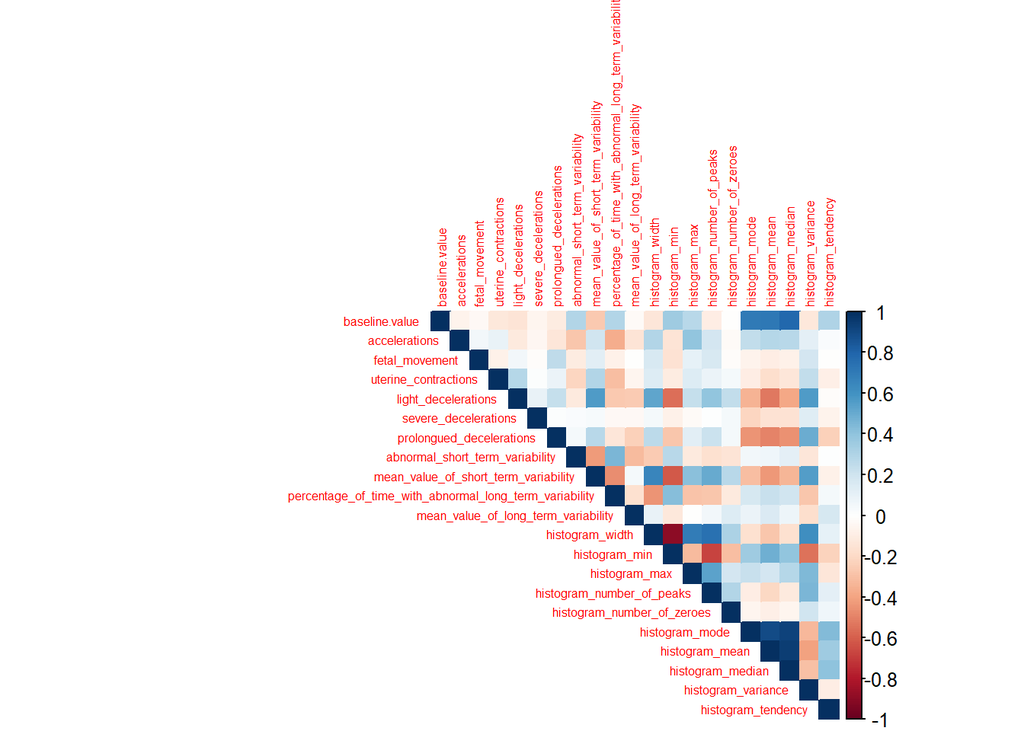

```r
# Correlation plot
fetal_health_train %>%
  select(where(is.numeric)) %>%
  cor() %>%
  corrplot(method = "color",
           type = "upper",
           tl.cex = 0.5)
```

> The above correlation plot shows that some variables, especially the histogram measures, are closely related to each other. Most other variables have weak or no correlation, meaning they give some unique information. This mix of strong and weak correlations suggests that while some predictors overlap, others could be quite helpful for classification.

Now make a bunch of boxplots (or violin) that are grouped by the target variable. There are a few ways we can do this.

Instead of creating separate plots for each variable, we could create a faceted plot, where we facet by the variable. To do this, we need to reshape our data from wide to long. We can do this using `tidyr::pivot_longer()`.

```r
# Reshaping the training data
fetal_health_long <- fetal_health_train %>%
  pivot_longer(cols = where(is.numeric),
    names_to = "variable",
    values_to = "value")
```

Now we can create the faceted plot using the long data.

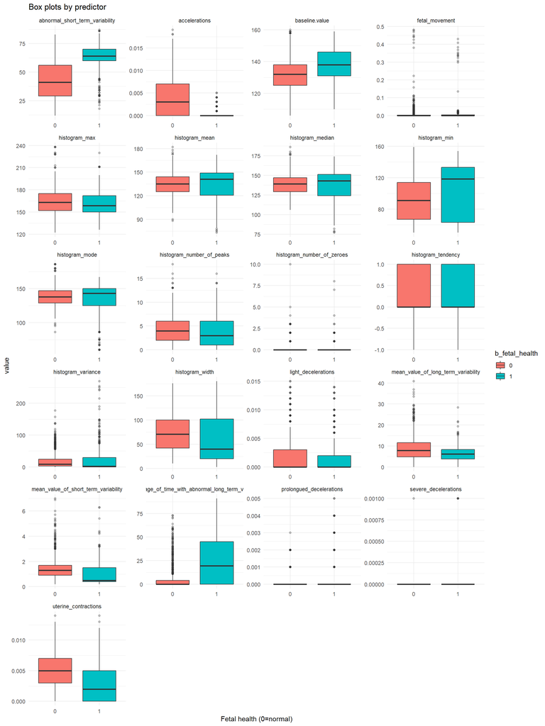

```r
#Faceted Box plot
fetal_health_long %>%
  ggplot(aes(x = b_fetal_health, y = value, fill = b_fetal_health)) +
  geom_boxplot(outlier.alpha = 0.3) +
  facet_wrap(~ variable, scales = "free", ncol = 4) +
  ggtitle("Box plots by predictor") +
  xlab("Fetal health (0=normal)") +
  theme_minimal()
```

> The above boxplots show that abnormal fetal health (1) is linked with higher baseline_value and short-term variability, but fewer with accelerations. Many histogram variables such as histogram_mean, histogram_mode, and histogram_tendency look similar for both the groups, so they might not be as helpful for prediction.

## Step 5 - Building and evaluation of predictive classification models

Now that you know a little more about the data, it’s time to start building a few classification models for `b_fetal_health`. We will use:

- logistic regression
- a simple decision tree
- a random forest

We will start out using overall prediction accuracy as our metric but we might want to consider other metrics.

**QUESTION** Why might overall prediction accuracy not be the most appropriate metric to consider? What other metrics might be important and why?

> Since most of the cases are normal, accuracy can look high even if the model misses many abnormal cases. Other metrics like sensitivity and specificity might be more important to measure real performance.

### The null model

A very simple model would be to simply predict that `b_fetal_health` is equal to 0. On the training data we saw that we’d be ~78% accurate.

**QUESTION** What is the sensitivity and specificity of the null model?

> For the null model, sensitivity = 0 and specificity = 1. The model correctly predicts all normal cases but misses every abnormal case. This gives high accuracy approx. 78% but is useless for detecting abnormal fetal health.

So, as we begin fitting more complicated models, remember that we need to outperform the null model to make it worth it to use more complicated models.

### Model 1 - logistic regression model

For logistic regression, you must use tidymodels and you should see our class notes on logistic regression, in particular, the section titled “Logistic regression with tidymodels”. For this modeling technique, you must:

- fit at least two different logistic regression models, each of which should have at least five variables. For your first model, use variables that you think might have predictive value based on the EDA you did. For the second model, use all of the variables.
- use 5-fold cross-validation as our resampling scheme for model fitting,
- just take the default threshold value of 0.5,
- assess the model’s performance on the training data (accuracy, sensitivity, specificity, confusion matrix),
- use the model to make predictions on the test data and assess the model’s performance on the test data,
- discuss the results.

**HACKER EXTRA CREDIT** Create ROC curves and compute AUC for your logistic regression models. Discuss your interpretation of these plots.

Start by creating a classification model object using the appropriate `engine =` argument for logistic regression.

```r
# Model Specification
glm_spec <- logistic_reg(mode = "classification", engine = "glm")
```

Create a recipe for your first model which specifies the formula for your logistic regression model.

```r
#Creating Recipe for first model
recipe_1 <- recipe(b_fetal_health ~ baseline.value + accelerations +
                     abnormal_short_term_variability +
                     mean_value_of_short_term_variability +
                     mean_value_of_long_term_variability,
                   data = fetal_health_train)
```

Now create a workflow object and the recipe and model to it.

```r
#Creating Workflow
wf_1 <- workflow() %>%
  add_recipe(recipe_1) %>%
  add_model(glm_spec)
```

Now we’ll create a folds object to use for k-crossfold validation.

```r
set.seed(259)
fetal_health_folds <- vfold_cv(fetal_health_train, v = 5)
ctrl_preds <- control_resamples(save_pred = TRUE, save_workflow = TRUE)
```

Now you should fit your logistic regression model using folds object we just created.

```r
fit_results_logreg1 <-
  wf_1 %>%
  fit_resamples(resamples = fetal_health_folds,
                control = ctrl_preds)
```

Now we can collect the metrics.

```r
collect_metrics(fit_results_logreg1)
```

```
# A tibble: 3 × 6
  .metric     .estimator   mean     n std_err .config
  <chr>       <chr>       <dbl> <int>   <dbl> <chr>
1 accuracy    binary     0.848      5 0.00839 pre0_mod0_post0
2 brier_class binary     0.0993     5 0.00278 pre0_mod0_post0
3 roc_auc     binary     0.911      5 0.00714 pre0_mod0_post0
```

Let’s refit on entire training data set and make predictions on the test data. Recall from the notes that we use the `last_fit` function to do this. Then we can use the `yardstick` package to compute accuracy, sensitivity and specificity.

```r
last_fit_logreg1 <- last_fit(wf_1,
                             split = fetal_health_split)

# These are prediction on the test data

final_predicted_classes_1 <- collect_predictions(last_fit_logreg1)

# Accuracy
acc_test_logreg1 <- yardstick::accuracy(final_predicted_classes_1,
                                        estimate = .pred_class,
                                        truth = b_fetal_health,
                                        event_level = "second")

# Do similar things for sensitivity and specificity.
sens_test_logreg1 <- yardstick::sens(final_predicted_classes_1,
                                     estimate = .pred_class,
                                     truth = b_fetal_health,
                                     event_level = "second")

spec_test_logreg1 <- yardstick::spec(final_predicted_classes_1,
                                     estimate = .pred_class,
                                     truth = b_fetal_health,
                                     event_level = "second")

# Combine the results into a single dataframe

stats_test_logreg1 <- bind_rows(acc_test_logreg1, sens_test_logreg1, spec_test_logreg1) %>%
  mutate(data = 'test',
         model = 'logreg1')

# Confusion matrix
yardstick::conf_mat(final_predicted_classes_1,
                    estimate = .pred_class,
                    truth = b_fetal_health)
```

```
          Truth
Prediction   0   1
         0 299  29
         1  32  66
```

```r
#Results
stats_test_logreg1
```

```
# A tibble: 3 × 5
  .metric  .estimator .estimate data  model
  <chr>    <chr>          <dbl> <chr> <chr>
1 accuracy binary         0.857 test  logreg1
2 sens     binary         0.695 test  logreg1
3 spec     binary         0.903 test  logreg1
```

> The model acheived around 85.6% accuracy on the test set. It correctly predicted most normal cases and identified approx. 70% of abnormal ones. Although it still misses some abnormal cases, it performs much better than the null model’s approx. 78% accuracy and is reasonably effective in detecting risky fetal health outcomes.

Let’s fit a second model using all of the variables.

```r
#Recipe for second model
recipe_2 <-
  recipe(b_fetal_health ~ .,
           data = fetal_health_train)

# Create your workflow object and add the recipe and model
wf_2 <- workflow() %>%
  add_recipe(recipe_2) %>%
  add_model(glm_spec)
```

Just like you did above, fit the model and assess its performance. Compare the results to the first logistic regression model. Use as many code chunks as needed.

```r
# Fitting logistic regression Model 2 with k-crossfold
fit_results_logreg2 <- wf_2 %>%
  fit_resamples(resamples = fetal_health_folds,
                control = ctrl_preds)
collect_metrics(fit_results_logreg2)
```

```
# A tibble: 3 × 6
  .metric     .estimator   mean     n std_err .config
  <chr>       <chr>       <dbl> <int>   <dbl> <chr>
1 accuracy    binary     0.905      5 0.00561 pre0_mod0_post0
2 brier_class binary     0.0654     5 0.00306 pre0_mod0_post0
3 roc_auc     binary     0.961      5 0.00399 pre0_mod0_post0
```

```r
last_fit_logreg2 <- last_fit(wf_2, split = fetal_health_split)

# Collecting predictions on the test data
final_predicted_classes_2 <- collect_predictions(last_fit_logreg2)

# Computing accuracy, sensitivity, and specificity
acc_test_logreg2 <- yardstick::accuracy(final_predicted_classes_2,
                                        estimate = .pred_class,
                                        truth = b_fetal_health,
                                        event_level = "second")

sens_test_logreg2 <- yardstick::sens(final_predicted_classes_2,
                                     estimate = .pred_class,
                                     truth = b_fetal_health,
                                     event_level = "second")

spec_test_logreg2 <- yardstick::spec(final_predicted_classes_2,
                                     estimate = .pred_class,
                                     truth = b_fetal_health,
                                     event_level = "second")

# Combine the results into a single dataframe
stats_test_logreg2 <- bind_rows(acc_test_logreg2, sens_test_logreg2, spec_test_logreg2) %>%
  mutate(data = 'test',
         model = 'logreg2')

# Confusion matrix
yardstick::conf_mat(final_predicted_classes_2,
                    estimate = .pred_class,
                    truth = b_fetal_health)
```

```
          Truth
Prediction   0   1
         0 312  14
         1  19  81
```

```r
# Results
stats_test_logreg2
```

```
# A tibble: 3 × 5
  .metric  .estimator .estimate data  model
  <chr>    <chr>          <dbl> <chr> <chr>
1 accuracy binary         0.923 test  logreg2
2 sens     binary         0.853 test  logreg2
3 spec     binary         0.943 test  logreg2
```

> The model achieved around 92.3% accuracy on the test set. It correctly predicted most normal cases and identified approximately 85% of abnormal ones. This shows a clear improvement over the first logistic model’s accuracy of 85.6% and the null model’s 78%. Overall, it performs very well in detecting both normal and abnormal fetal health outcomes.

Hacker Extra Credit

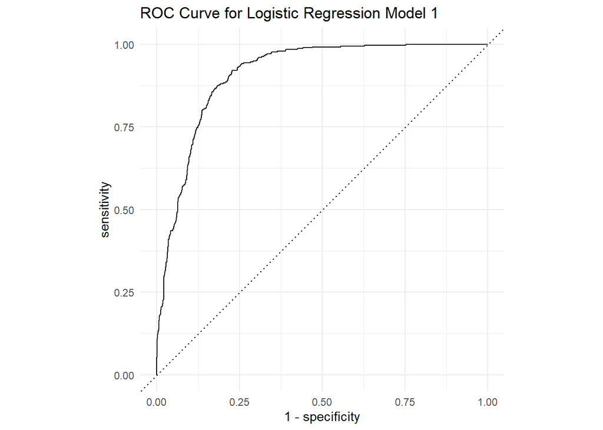

```r
# ROC Curve and AUC for Logistic Regression Model 1

roc_logreg1 <- collect_predictions(fit_results_logreg1) %>%
  roc_curve(truth = b_fetal_health, .pred_1, event_level = "second")

autoplot(roc_logreg1) +
  ggtitle("ROC Curve for Logistic Regression Model 1") +
  theme_minimal()
```

```r
auc_logreg1 <- collect_predictions(fit_results_logreg1) %>%
  roc_auc(truth = b_fetal_health, .pred_1, event_level = "second")

auc_logreg1
```

```
# A tibble: 1 × 3
  .metric .estimator .estimate
  <chr>   <chr>          <dbl>
1 roc_auc binary         0.910
```

> The above ROC curve shows that the model works really well. The AUC is 0.91, which means it can tell the difference between normal and abnormal fetal health about 91% of the time. This is a very good result for this dataset.

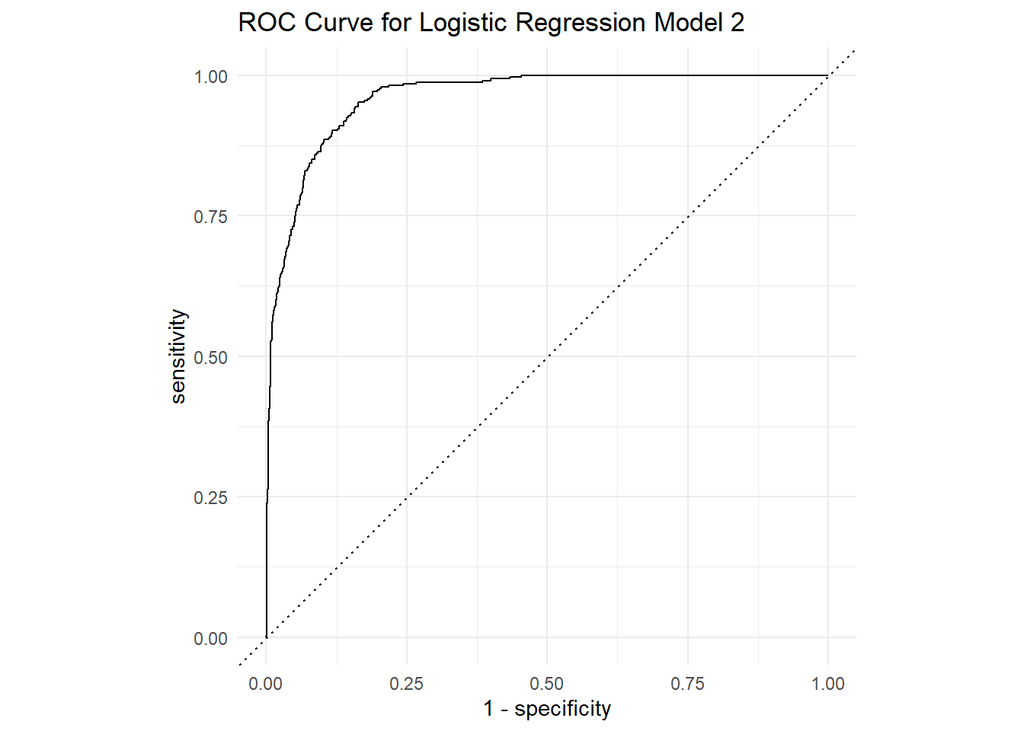

```r
# ROC Curve and AUC for Logistic Regression Model 2

roc_logreg2 <- collect_predictions(fit_results_logreg2) %>%
  roc_curve(truth = b_fetal_health, .pred_1, event_level = "second")

autoplot(roc_logreg2) +
  ggtitle("ROC Curve for Logistic Regression Model 2") +
  theme_minimal()
```

```r
auc_logreg2 <- collect_predictions(fit_results_logreg2) %>%
  roc_auc(truth = b_fetal_health, .pred_1, event_level = "second")

auc_logreg2
```

```
# A tibble: 1 × 3
  .metric .estimator .estimate
  <chr>   <chr>          <dbl>
1 roc_auc binary         0.961
```

> The above ROC curve shows that the model works really well. The AUC is 0.96, which means it can tell the difference between normal and abnormal fetal health about 96% of the time. This is an excellent result for this dataset and even better than the first logistic regression model.

### Model 2 - a simple decision tree

For this model, we will **NOT** use a resampling scheme (i.e. no k-fold cross-validation). We will just use our one simple train-test split. We’ll use `rpart` for the engine, just as we did in the notes.

Create your model specification.

```r
# Model specification Decision Tree
tree_spec <- decision_tree() %>%
  set_engine("rpart") %>%
  set_mode("classification")
```

Let’s fit a tree to the training data using just a few variables so that we can easily see what’s going on.

```r
#Fitting the tree on training data
tree1_fit <- fit(tree_spec, b_fetal_health ~
           accelerations +
           baseline.value +
           histogram_median + +
           uterine_contractions, data = fetal_health_train)
```

Let’s see what the fitted object looks like.

```r
tree1_fit
```

```
parsnip model object

n= 1700

node), split, n, loss, yval, (yprob)
      * denotes terminal node

  1) root 1700 376 0 (0.77882353 0.22117647)
    2) accelerations>=0.0005 988  62 0 (0.93724696 0.06275304)
      4) histogram_median>=113.5 956  41 0 (0.95711297 0.04288703) *
      5) histogram_median< 113.5 32  11 1 (0.34375000 0.65625000)
       10) baseline.value< 121 16   5 0 (0.68750000 0.31250000) *
       11) baseline.value>=121 16   0 1 (0.00000000 1.00000000) *
    3) accelerations< 0.0005 712 314 0 (0.55898876 0.44101124)
      6) uterine_contractions>=0.0025 445 138 0 (0.68988764 0.31011236)
       12) histogram_median>=111.5 402  99 0 (0.75373134 0.24626866)
         24) histogram_median< 147.5 317  49 0 (0.84542587 0.15457413)
           48) baseline.value< 127.5 115   3 0 (0.97391304 0.02608696) *
           49) baseline.value>=127.5 202  46 0 (0.77227723 0.22772277)
             98) histogram_median>=120.5 184  31 0 (0.83152174 0.16847826) *
             99) histogram_median< 120.5 18   3 1 (0.16666667 0.83333333) *
         25) histogram_median>=147.5 85  35 1 (0.41176471 0.58823529) *
       13) histogram_median< 111.5 43   4 1 (0.09302326 0.90697674) *
      7) uterine_contractions< 0.0025 267  91 1 (0.34082397 0.65917603)
       14) baseline.value< 122.5 31   7 0 (0.77419355 0.22580645) *
       15) baseline.value>=122.5 236  67 1 (0.28389831 0.71610169)
         30) baseline.value< 143.5 149  57 1 (0.38255034 0.61744966)
           60) uterine_contractions>=0.0015 26   9 0 (0.65384615 0.34615385) *
           61) uterine_contractions< 0.0015 123  40 1 (0.32520325 0.67479675)
            122) histogram_median>=146.5 10   3 0 (0.70000000 0.30000000) *
            123) histogram_median< 146.5 113  33 1 (0.29203540 0.70796460) *
         31) baseline.value>=143.5 87  10 1 (0.11494253 0.88505747) *
```

The `rpart.plot()` function lets us see the actual (upside down) tree. Since this function only works with `rpart` objects, we need to extract it from our `fit` object.

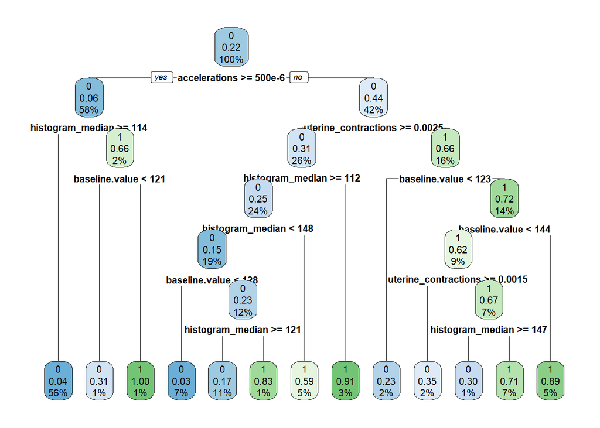

```r
tree1_fit %>%
  extract_fit_engine() %>%
  rpart.plot(tweak = 1.2)
```

**QUESTION** Explain each of the values in the node in the third row from the top in the middle (light blue with values 0, 0.31 and 26%) What conditions need to be true for a case to end up in that node?

Now use `augment()` function along with `yardstick::sens()`, `yardstick::spec()`, and `yardstick::conf_mat()` to compute sensitivity, specificity, and the confusion matrix on the **training data**. In other words, we are just assessing how well the tree fits the data.

Notice in the code skeleton that I’m explicitly specifying the **yardstick** package and a function from it. I’m doing that because the `spec` function name clashes with another library we have loaded - you can see this by doing a `help(spec)`. Also notice that we need `event_level = "second"` since “0” comes before “1” in the factor levels for `b_fetal_health` and it’s the “1”’s that are the thing we are trying to detect (abnormal results). We need `event_level = “second” for accuracy, sensitivity and specificity calculations (we don’t need it for the confusion matrix).

```r
# Accuracy
acc_train_tree <- augment(tree1_fit, new_data = fetal_health_train) %>%
  yardstick::accuracy(
    truth = b_fetal_health,
    estimate = .pred_class,
    event_level = "second"
  )

# Sensitivity
sens_train_tree <- augment(tree1_fit, new_data = fetal_health_train) %>%
  yardstick::sens(
    truth = b_fetal_health,
    estimate = .pred_class,
    event_level = "second"
  )

# Specificity
spec_train_tree <- augment(tree1_fit, new_data = fetal_health_train) %>%
  yardstick::spec(
    truth = b_fetal_health,
    estimate = .pred_class,
    event_level = "second"
  )

# Combine the results into a single dataframe
stats_train_tree1 <- bind_rows(acc_train_tree, sens_train_tree, spec_train_tree) %>%
  mutate(data = "train",
         model = "tree1")

# Confusion Matrix
augment(tree1_fit, new_data = fetal_health_train) %>%
  yardstick::conf_mat(
    truth = b_fetal_health,
    estimate = .pred_class
  )
```

```
          Truth
Prediction    0    1
         0 1239   99
         1   85  277
```

```r
#Results
stats_train_tree1
```

```
# A tibble: 3 × 5
  .metric  .estimator .estimate data  model
  <chr>    <chr>          <dbl> <chr> <chr>
1 accuracy binary         0.892 train tree1
2 sens     binary         0.737 train tree1
3 spec     binary         0.936 train tree1
```

> The model performed well on the training data with 89.2% accuracy, 73.7% sensitivity, and 93.6% specificity. This means it correctly predicted most normal fetal health cases and detected a majority of the abnormal ones, indicating a good balance between identifying healthy and risky outcomes.

**QUESTION** What is the predicted class and the probabilities of 0 and 1 for the very first row in `fetal_health_train`? **HINT** There is nothing to compute - you just need to look at the appropriate tibble and you’ve already used this tibble above.

```r
augment(tree1_fit, new_data = fetal_health_train) %>%
  slice(1)
```

```
# A tibble: 1 × 25
  .pred_class .pred_0 .pred_1 baseline.value accelerations fetal_movement
  <fct>         <dbl>   <dbl>          <dbl>         <dbl>          <dbl>
1 0             0.957  0.0429            132         0.006              0
# ℹ 19 more variables: uterine_contractions <dbl>, light_decelerations <dbl>,
#   severe_decelerations <dbl>, prolongued_decelerations <dbl>,
#   abnormal_short_term_variability <dbl>,
#   mean_value_of_short_term_variability <dbl>,
#   percentage_of_time_with_abnormal_long_term_variability <dbl>,
#   mean_value_of_long_term_variability <dbl>, histogram_width <dbl>,
#   histogram_min <dbl>, histogram_max <dbl>, …
```

Now, make predictions for the test data for this first tree and compute sensitivity, specificity and the confusion matrix. Remember (see notes) that you can use the `augment()` function to compute predicted values for the test data.

```r
# Accuracy
acc_test_tree <- augment(tree1_fit, new_data = fetal_health_test) %>%
  yardstick::accuracy(
    truth = b_fetal_health,
    estimate = .pred_class,
    event_level = "second")

# Sensitivity
sens_test_tree <- augment(tree1_fit, new_data = fetal_health_test) %>%
  yardstick::sens(
    truth = b_fetal_health,
    estimate = .pred_class,
    event_level = "second")

# Specificity
spec_test_tree <- augment(tree1_fit, new_data = fetal_health_test) %>%
  yardstick::spec(
    truth = b_fetal_health,
    estimate = .pred_class,
    event_level = "second")

# Combine the results into a single dataframe
stats_test_tree1 <- bind_rows(acc_test_tree, sens_test_tree, spec_test_tree) %>%
  mutate(data = "test",
         model = "tree1")

# Confusion matrix
augment(tree1_fit, new_data = fetal_health_test) %>%
  yardstick::conf_mat(
    truth = b_fetal_health,
    estimate = .pred_class)
```

```
          Truth
Prediction   0   1
         0 308  28
         1  23  67
```

```r
#Results
stats_test_tree1
```

```
# A tibble: 3 × 5
  .metric  .estimator .estimate data  model
  <chr>    <chr>          <dbl> <chr> <chr>
1 accuracy binary         0.880 test  tree1
2 sens     binary         0.705 test  tree1
3 spec     binary         0.931 test  tree1
```

**QUESTION** Compare the results to what you got on the training data. Did the metrics get better or worse? Is this expected? Why? Is there evidence of overfitting?

Here’s some code that could be useful in organizing and comparing the results.

```r
stats_tree1 <- bind_rows(stats_train_tree1, stats_test_tree1)
stats_tree1 %>%
  select(.metric, .estimate, data) %>%
  pivot_wider(
    names_from = data,
    values_from = .estimate)
```

```
# A tibble: 3 × 3
  .metric  train  test
  <chr>    <dbl> <dbl>
1 accuracy 0.892 0.880
2 sens     0.737 0.705
3 spec     0.936 0.931
```

> The simple decision tree achieved about 89% accuracy on the training data and 88% on the test data. Sensitivity decreased slightly from 0.74 to 0.71, while specificity stayed stable around 0.93. The performance on the test data is close to that of the training data this indicates that the model is not overfitting and performs consistently in identifying both normal and abnormal fetal health cases.

Now, we’ll clean up the workspace a bit before trying the random forest.

```r
rm(tree1_fit)
```

### Model 3 - Random Forest

Instead of using a simple decision tree, use a random forest. Obviously, you should now use all the variables that you think might be useful for predicting `b_fetal_health`.

- fit the model on the training data,
- assess the model’s performance on the training data using the `augment()` function like we did for the decision tree,
- use the model to make predictions on the test data and assess the model’s performance on the test data using the `augment()` function,
- create an importance plot to get a sense of the relative importance of the different variables,
- discuss the results

In your discussion of the results you should talk about things like:

- how accurate is the model in predicting on the test data?
- is their evidence of overfitting?
- how does the model do in terms of other metrics like sensitivity and specificity?
- how does the performance of the random forest compare to the simple decision tree?

```r
#Model Specification Random Forest
rf_spec <- rand_forest() %>%
  set_engine("randomForest", importance = TRUE, na.action = na.omit) %>%
  set_mode("classification")
```

Fit the model

```r
# Fitting the random forest model on training data
rf_fit <- fit(rf_spec,
              b_fetal_health ~ .,
              data = fetal_health_train)
```

Compute accuracy, sensitivity and specificity for the fit.

```r
# Accuracy
acc_train_rf <- augment(rf_fit, new_data = fetal_health_train) %>%
  yardstick::accuracy(
    truth = b_fetal_health,
    estimate = .pred_class,
    event_level = "second")

# Sensitivity
sens_train_rf <- augment(rf_fit, new_data = fetal_health_train) %>%
  yardstick::sens(
    truth = b_fetal_health,
    estimate = .pred_class,
    event_level = "second")

# Specificity
spec_train_rf <- augment(rf_fit, new_data = fetal_health_train) %>%
  yardstick::spec(
    truth = b_fetal_health,
    estimate = .pred_class,
    event_level = "second")

# Combine the results into a single dataframe
stats_train_rf <- bind_rows(acc_train_rf, sens_train_rf, spec_train_rf) %>%
  mutate(data = "train", model = "rf")

# Confusion matrix
augment(rf_fit, new_data = fetal_health_train) %>%
  yardstick::conf_mat(
    truth = b_fetal_health,
    estimate = .pred_class)
```

```
          Truth
Prediction    0    1
         0 1324    1
         1    0  375
```

```r
# Results
stats_train_rf
```

```
# A tibble: 3 × 5
  .metric  .estimator .estimate data  model
  <chr>    <chr>          <dbl> <chr> <chr>
1 accuracy binary         0.999 train rf
2 sens     binary         0.997 train rf
3 spec     binary         1     train rf
```

Let’s look at an importance plot to get a sense of which variables seem to be influential.

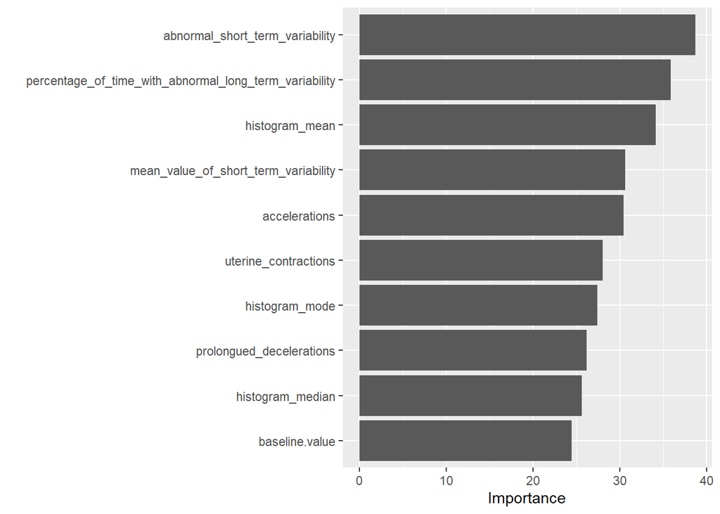

```r
#Variable Importance plot
vip(rf_fit)
```

Now let’s compute accuracy, sensitivity and specificity on the test data.

```r
# Accuracy
acc_test_rf <- augment(rf_fit, new_data = fetal_health_test) %>%
  yardstick::accuracy(
    truth = b_fetal_health,
    estimate = .pred_class,
    event_level = "second"
  )

# Sensitivity
sens_test_rf <- augment(rf_fit, new_data = fetal_health_test) %>%
  yardstick::sens(
    truth = b_fetal_health,
    estimate = .pred_class,
    event_level = "second"
  )

# Specificity
spec_test_rf <- augment(rf_fit, new_data = fetal_health_test) %>%
  yardstick::spec(
    truth = b_fetal_health,
    estimate = .pred_class,
    event_level = "second"
  )

# Combine the results into a single dataframe
stats_test_rf <- bind_rows(acc_test_rf, sens_test_rf, spec_test_rf) %>%
  mutate(data = 'test', model = 'rf')

# Confusion Matrix
augment(rf_fit, new_data = fetal_health_test) %>%
  yardstick::conf_mat(truth = b_fetal_health, estimate = .pred_class)
```

```
          Truth
Prediction   0   1
         0 323  16
         1   8  79
```

```r
#Results
stats_test_rf
```

```
# A tibble: 3 × 5
  .metric  .estimator .estimate data  model
  <chr>    <chr>          <dbl> <chr> <chr>
1 accuracy binary         0.944 test  rf
2 sens     binary         0.832 test  rf
3 spec     binary         0.976 test  rf
```

How do test and train performance compare?

```r
rm(rf_fit)
```

## Final model comparisons

So, if you had to recommend a model to consider using in practice, which of the models (if any) would you recommend and why?